# md4036_viz_part_02

Margaret

2022-10-10

```r
library(tidyverse)
library(ggridges)
```

Using same weather dataset

```r
weather_df =
  rnoaa::meteo_pull_monitors(
    c("USW00094728", "USC00519397", "USS0023B17S"),
    var = c("PRCP", "TMIN", "TMAX"),
    date_min = "2017-01-01",
    date_max = "2017-12-31") %>%
  mutate(
    name = recode(
      id,
      USW00094728 = "CentralPark_NY",
      USC00519397 = "Waikiki_HA",
      USS0023B17S = "Waterhole_WA"),
    tmin = tmin / 10,
    tmax = tmax / 10) %>%
  select(name, id, everything())
```

```
## using cached file: ~/Library/Caches/R/noaa_ghcnd/USW00094728.dly
```

```
## date created (size, mb): 2022-09-19 20:14:31 (8.402)
```

```
## file min/max dates: 1869-01-01 / 2022-09-30
```

```
## using cached file: ~/Library/Caches/R/noaa_ghcnd/USC00519397.dly
```

```
## date created (size, mb): 2022-09-19 20:14:38 (1.697)
```

```
## file min/max dates: 1965-01-01 / 2020-02-29
```

```
## using cached file: ~/Library/Caches/R/noaa_ghcnd/USS0023B17S.dly
```

```
## date created (size, mb): 2022-09-19 20:14:42 (0.95)
```

```
## file min/max dates: 1999-09-01 / 2022-09-30
```

Lets do better this time. Labs() names the x and y axis. Title sets the overall title for the graph and the caption is at the bottom telling the person what the graph is about.

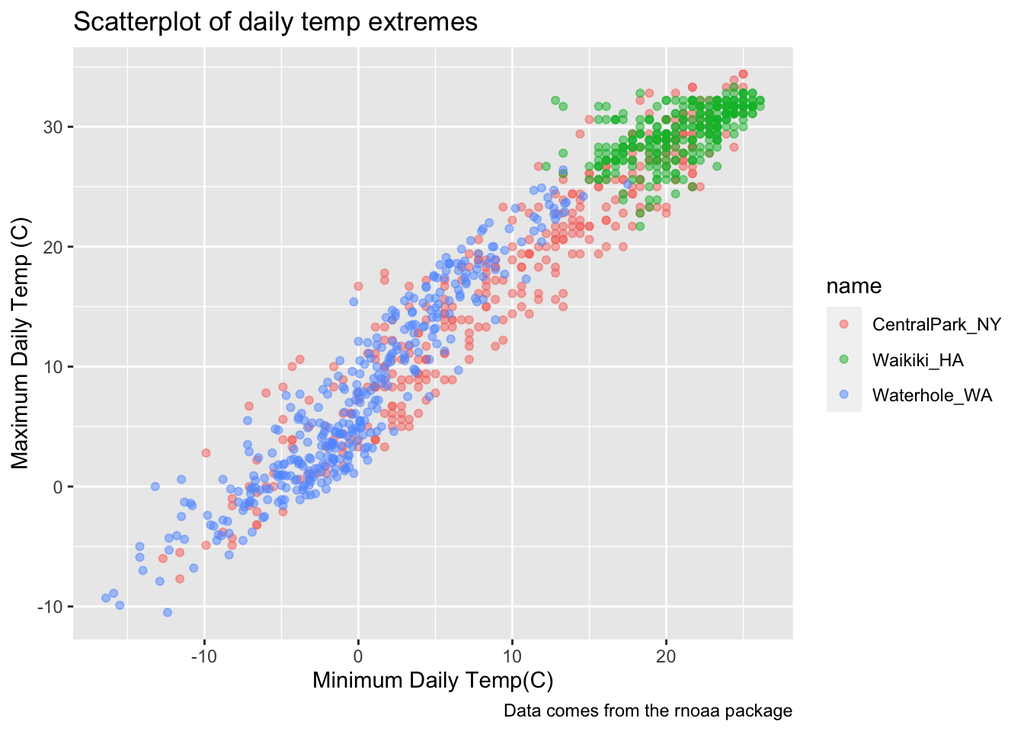

```r
weather_df %>%
  ggplot(aes(x = tmin, y = tmax, color = name)) +
  geom_point(alpha = .5) +
  labs(
    x = "Minimum Daily Temp(C)",
    y = "Maximum Daily Temp (C)",
    title = "Scatterplot of daily temp extremes",
    caption = "Data comes from the rnoaa package"
  )
```

This is how you do the scale transformations. Breaks gives it axis breaks. The scale_x_continuous modified the scale on the x-axis to be -10,0. 15 instead of -10,0,10,20. Labels then labels the scale on the x axis.

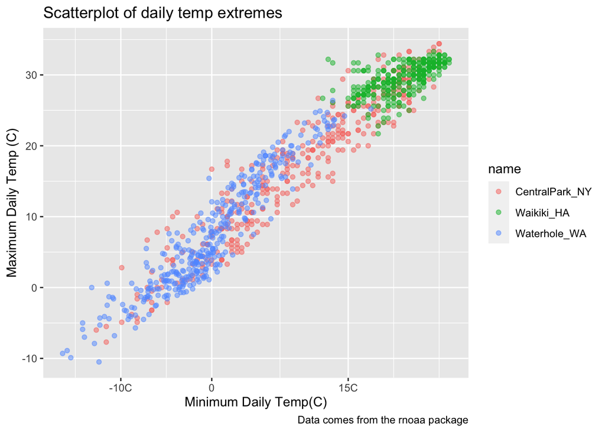

```r
weather_df %>%
  ggplot(aes(x = tmin, y = tmax, color = name)) +
  geom_point(alpha = .5) +
  labs(
    x = "Minimum Daily Temp(C)",
    y = "Maximum Daily Temp (C)",
    title = "Scatterplot of daily temp extremes",
    caption = "Data comes from the rnoaa package"
  ) +
  scale_x_continuous(
    breaks = c(-10, 0, 15),
    labels = c("-10C","0","15C")
  )
```

Here we are going to add on scale y continuous. the trans() create a transformation on the values - here: its square roots the y axis

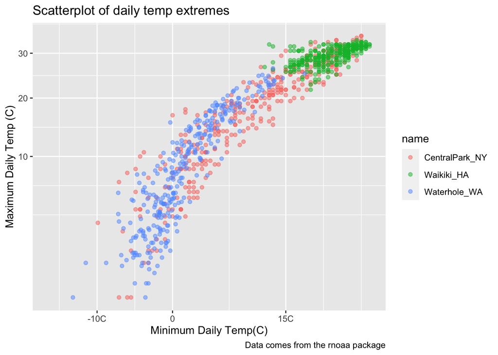

```r
weather_df %>%
  ggplot(aes(x = tmin, y = tmax, color = name)) +
  geom_point(alpha = .5) +
  labs(
    x = "Minimum Daily Temp(C)",
    y = "Maximum Daily Temp (C)",
    title = "Scatterplot of daily temp extremes",
    caption = "Data comes from the rnoaa package"
  ) +
  scale_x_continuous(
    breaks = c(-10, 0, 15),
    labels = c("-10C","0","15C")) +
  scale_y_continuous(
    trans = "sqrt"
  )
```

Now adding different colors to the chart: use scale_color_hue(). Use name = “” to also indicate to change thr colors in the legend. also can type in `viridis::scale_color_viridis`

```r
ggp_weather =
weather_df %>%
  ggplot(aes(x = tmin, y = tmax, color = name)) +
  geom_point(alpha = .5) +
  labs(
    x = "Minimum Daily Temp(C)",
    y = "Maximum Daily Temp (C)",
    title = "Scatterplot of daily temp extremes",
    caption = "Data comes from the rnoaa package"
  ) +
  scale_color_hue(
    name = "location",
    h = c(100,300))
```

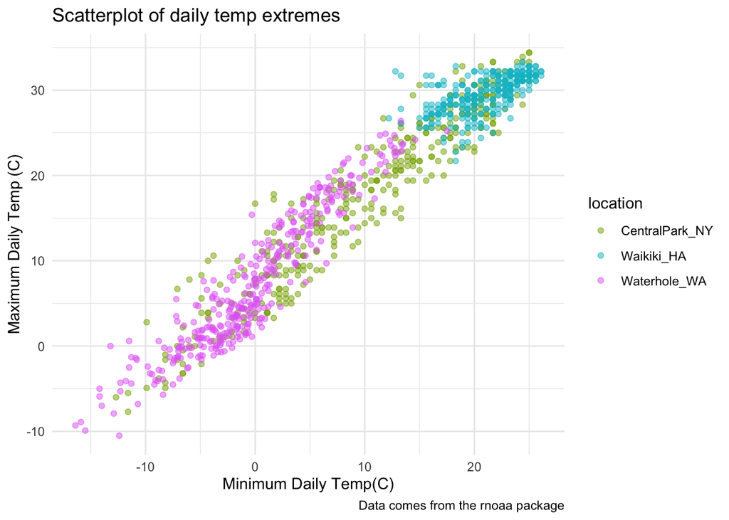

```r
ggp_weather +
  theme_minimal()
```

```r
  theme(legend.position = "bottom")
```

```
## List of 1
##  $ legend.position: chr "bottom"
##  - attr(*, "class")= chr [1:2] "theme" "gg"
##  - attr(*, "complete")= logi FALSE
##  - attr(*, "validate")= logi TRUE
```

##Data in Geom()

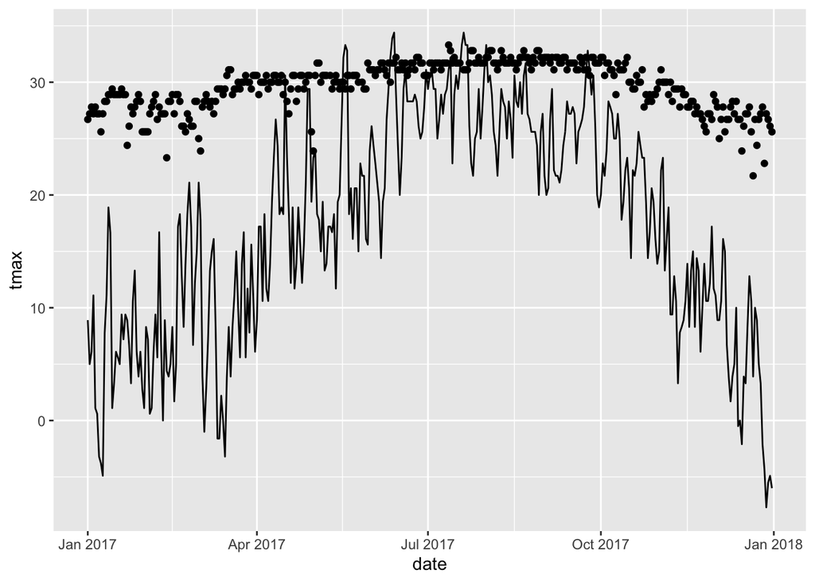

```r
central_park_df =
  weather_df%>%
  filter(name == "CentralPark_NY")

waikiki_df =
  weather_df %>%
  filter (name == "Waikiki_HA")

ggplot(waikiki_df, aes(x = date, y = tmax)) +
  geom_point() +
  geom_line(data = central_park_df)
```

## Patchwork

want to show different panels based on a variable: facet_grid(). BUT if you want to make 2 separate fundamentally diff figures:

```r
tmax_tmin_plot =
  weather_df %>%
  ggplot(aes(x = tmin, y = tmax, color = name)) +
  geom_point()

prcp_density_plot =
  weather_df %>%
  filter(prcp>0)%>%
  ggplot(aes(x = prcp, fill = name)) +
  geom_density(alpha = .5)

seasonality_df =
  weather_df %>%
  ggplot (aes(x = date, y = tmax, color = name)) +
  geom_point(alpha = .5) +
  geom_smooth(se = FALSE)+
  theme(legend.position = "none")
```

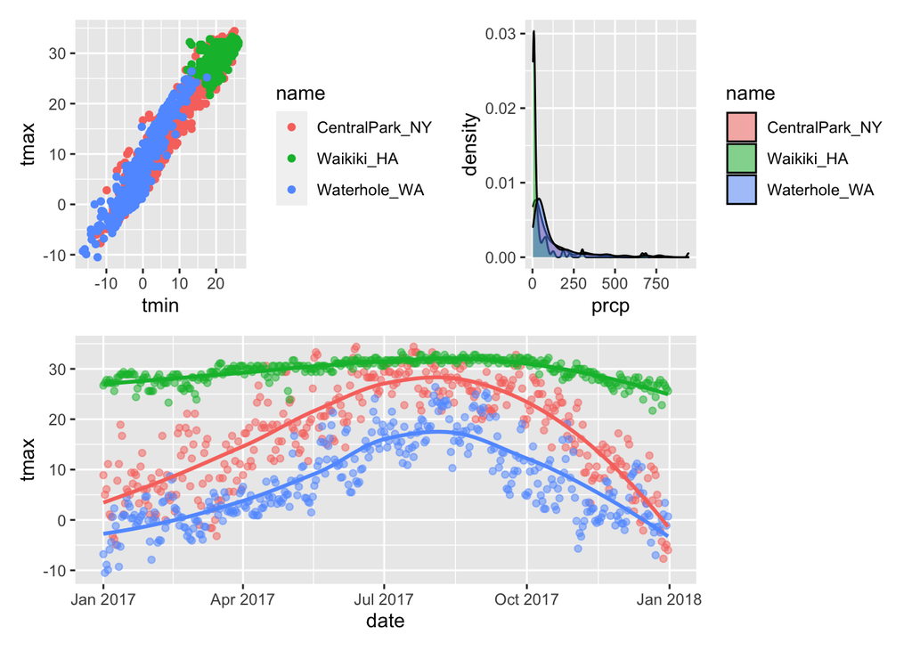

```r
library(patchwork)
(tmax_tmin_plot + prcp_density_plot)/seasonality_df
```

##Data Manipulation Here, fct_relevel() helps you reorganize the graphs. Here we made it so it would display the waikiki first out of the 3 locations.

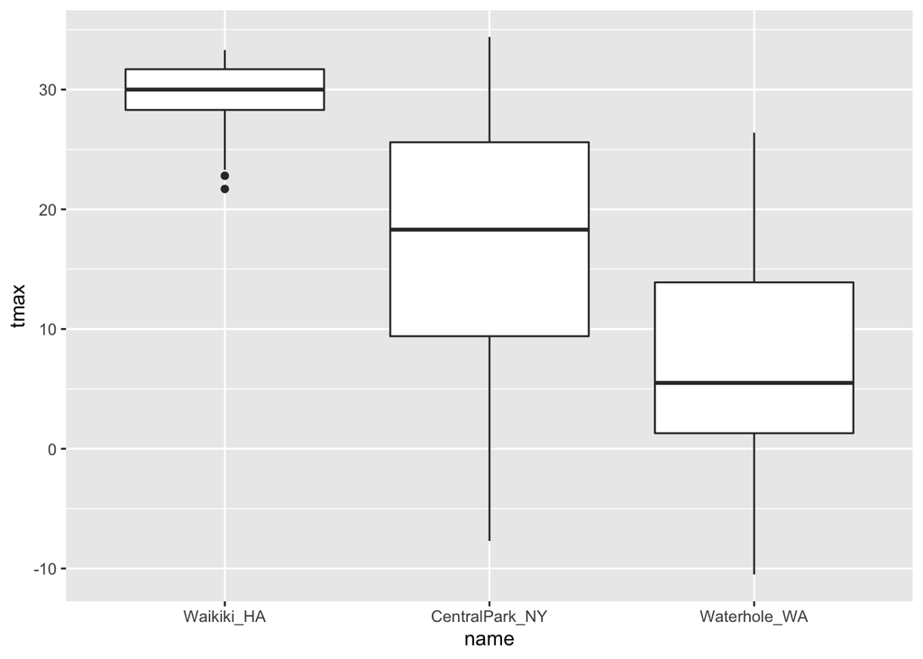

```r
weather_df%>%
  mutate(name = fct_relevel(name, "Waikiki_HA"))%>%
  ggplot(aes (x = name, y = tmax))+
  geom_boxplot()
```

You can also use fct_reorder() to order a variable in terms of tmax. This will spit out graphs in order of lowest average to highest average

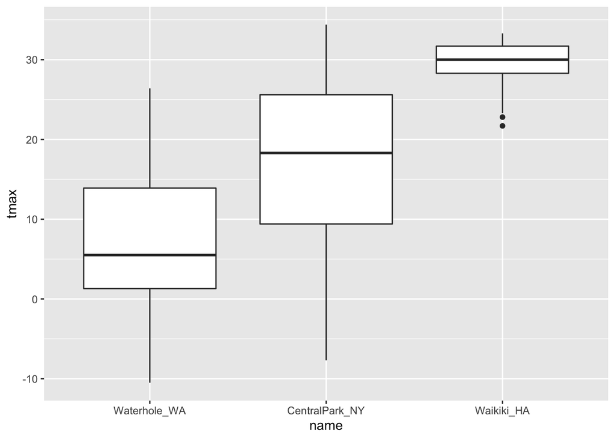

```r
weather_df%>%
  mutate(name = fct_reorder(name, tmax))%>%
  ggplot(aes (x = name, y = tmax))+
  geom_boxplot()
```